# Software for Data Analysis - Project 2

## 6.1 Confidence Intervals

Table below in this section shows confidence intervals for the same parameters from bootstrapping with 1500 resamples using the best fitted method explained earlier.

```r
table1 <- rbind(quantile(bootResult[,1], probs = c(0.025, 0.975)),
                quantile(bootResult[,2], probs = c(0.025, 0.975)),
                quantile(bootResult[,3], probs = c(0.025, 0.975)),
                quantile(bootResult[,4], probs = c(0.025, 0.975)),
                quantile(bootResult[,5], probs = c(0.025, 0.975)))
kable(table1, caption = "Confidence Intervals")
```

Confidence Intervals

| 2.5% | 97.5% |
| --- | --- |
| 106.7832770 | 124.1459904 |
| -0.3835319 | -0.1668866 |
| -0.0962467 | 0.0147804 |
| -3.0867602 | -2.4690496 |
| -0.1607062 | -0.1022546 |

## 6.2 Linearity

Looking at the QQ plot after bootstrapping for instance we can see a reasonable sign that the coefficients are normally distributed:

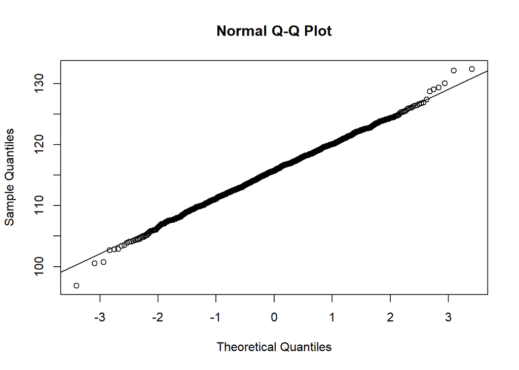

```r
qqnorm(bootResult[,1])
qqline(bootResult[,1])
```

Running shapiro test can confirm the normality by showing p-value of 0.24 as below which does not have enough evidence to reject null hypothesis of shapiro test.

```r
shapiro.test(bootResult[,1])
```

```
##
##  Shapiro-Wilk normality test
##
## data:  bootResult[, 1]
## W = 0.99855, p-value = 0.2398
```

# 7 References"

- “Toturial and lecture activities” by Dr.Donavan - MT5763
- Tilman M.Davies (2016). The book of R.
- Rawlings (1998) Applied Regression Analysis: A Research Tool 2nd Edition,http://web.nchu.edu.tw/~numerical/course992/ra/Applied_Regression_Analysis_A_Research_Tool.pdf